# STEPS

### 1. Import Data

### 2. Descriptive Statistics

### 3. Missings Treatment

Criteria for Missing Imputation:

- Stationary Series, missings are replace with the mean (expected value)
- Non-Stationary Time Series,

  ```
    -> if a clear trend is visible, a spline interpolation of order 1 is used
    -> Otherwise, a reverse autoregressive model is calculated to recreate the past values.
       Time series data are sorted in descending order and and past values are "forecasted" through an arima model
       The missing observation at 2019 has been sobstituted with forward fill.
  ```

### 5. Computation of stationary series

Diff() function is applied untill all the variables verify the stationary assumption

### 7. Granger Causality Test

Granger Causality test is run to inspect the causality dependence between X and Y.  
X Granger causes Y if lagged values of X help to predict current and future values of Y better that just lagged values of Y alone (test for joint significance). A reduced set of variables is selected based on the output of the test.

### 8. Model Estimation

The best fit patameter is inspected through AIC metrics. Model parameters are estimated and an autocorellation analysis on residuals is conducted.

### 9. Forecasting GDP

A one-year forecast for GDP is done based on the estimated model (for five consecutive years 2015 - 2019). Plots and Metrics are reported below.

```python
import pandas as pd
import numpy as np
import matplotlib.pyplot as plt
```

# 1. Import Data

```python
path = r"C:\Users\Utente\Desktop\UBS Project\Sorted data.csv" #adjust the path whithin quotation marks
df = pd.read_csv(path).set_index("Year")
print(df.shape)
df.tail(10)
```

```
(60, 19)
```

| Year | imp_exp | dom_credit | gov_exp | inventory | gdp_t0 | consumption | infl | market_cap | air_transp | risk_premium | pop | oil | trade_index | wages | energy | unemp | contr_family | employers | self_employed |
| --- | --- | --- | --- | --- | --- | --- | --- | --- | --- | --- | --- | --- | --- | --- | --- | --- | --- | --- | --- |
| 2010 | -4.014430e+11 | 1.461140e+13 | 2.762080e+12 | 5.703862e+10 | 1.634570e+13 | 1.096710e+13 | 100.000000 | 1.728350e+13 | 10095197.0 | 3.115833 | 309321666 | 0.317967 | 97.082019 | 3.926630e+11 | 7161.553355 | 9.6334 | 0.084 | 2.846 | 7.045 |
| 2011 | -3.957070e+11 | 1.549690e+13 | 2.678710e+12 | 4.650774e+10 | 1.659920e+13 | 1.117410e+13 | 103.156842 | 1.564070e+13 | 10057768.0 | 3.192500 | 311556874 | 0.455621 | 94.594595 | 4.008100e+11 | 7030.554961 | 8.9492 | 0.076 | 2.741 | 6.820 |
| 2012 | -3.922290e+11 | 1.604660e+13 | 2.639650e+12 | 7.090819e+10 | 1.697260e+13 | 1.134200e+13 | 105.291504 | 1.866830e+13 | 9864360.0 | 3.162500 | 313830990 | 0.291285 | 94.680851 | 3.979700e+11 | 6873.049271 | 8.0694 | 0.077 | 2.697 | 6.753 |
| 2013 | -3.558160e+11 | 1.739430e+13 | 2.589590e+12 | 1.081910e+11 | 1.728530e+13 | 1.150690e+13 | 106.833849 | 2.403490e+13 | 9745498.0 | 3.190833 | 315993715 | 0.360372 | 95.340502 | 3.883410e+11 | 6907.046040 | 7.3749 | 0.070 | 2.620 | 6.595 |
| 2014 | -3.905500e+11 | 1.841260e+13 | 2.569450e+12 | 8.593083e+10 | 1.770910e+13 | 1.184760e+13 | 108.566932 | 2.633060e+13 | 9556324.0 | 3.215000 | 318301008 | 0.308606 | 95.869565 | 3.925430e+11 | 6962.549817 | 6.1675 | 0.059 | 2.548 | 6.446 |
| 2015 | -5.198450e+11 | 1.896110e+13 | 2.616250e+12 | 1.318700e+11 | 1.821930e+13 | 1.228430e+13 | 108.695722 | 2.506750e+13 | 9498668.0 | 3.207500 | 320635163 | 0.008301 | 100.000000 | 3.992210e+11 | 6806.199939 | 5.2800 | 0.067 | 2.528 | 6.444 |
| 2016 | -5.756420e+11 | 1.989220e+13 | 2.663340e+12 | 2.288993e+10 | 1.850480e+13 | 1.262050e+13 | 110.067009 | 2.735220e+13 | 9640591.0 | 3.194167 | 322941311 | 0.092415 | 100.083472 | 4.099850e+11 | NaN | 4.8692 | 0.058 | 2.494 | 6.387 |
| 2017 | -6.305920e+11 | 2.081510e+13 | 2.678800e+12 | 3.152294e+10 | 1.891510e+13 | 1.294970e+13 | 112.411557 | 3.212070e+13 | 9639096.0 | 3.165833 | 324985539 | 0.177409 | 99.594485 | 4.200780e+11 | NaN | 4.3552 | 0.050 | 2.429 | 6.252 |
| 2018 | -6.897830e+11 | 2.110410e+13 | 2.723090e+12 | 4.793960e+10 | 1.946880e+13 | 1.333880e+13 | 115.157303 | 3.043630e+13 | 9879630.0 | 2.965000 | 326687501 | 0.376622 | 99.842644 | 4.385940e+11 | NaN | 3.8956 | 0.062 | 2.420 | 6.281 |
| 2019 | NaN | 2.228830e+13 | NaN | NaN | 1.992310e+13 | NaN | 117.244196 | NaN | NaN | 3.210833 | 328239523 | NaN | NaN | 4.562830e+11 | NaN | 3.6692 | 0.060 | 2.382 | 6.218 |

```
array([[<matplotlib.axes._subplots.AxesSubplot object at 0x0000024F4100CB20>,
      dtype=object)
```

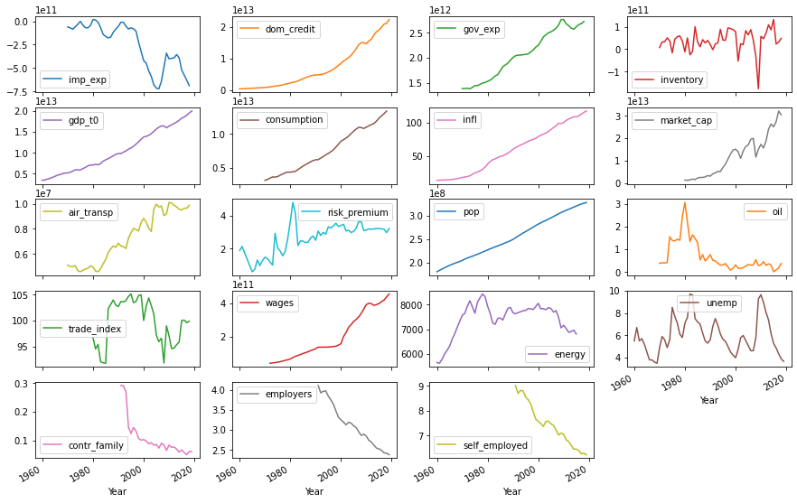

```python
df.plot(subplots=True,layout= (5,4), figsize=(15,10))
```

# 2. Descriptive Statistics

```python
df.describe()
```

|  | imp_exp | dom_credit | gov_exp | inventory | gdp_t0 | consumption | infl | market_cap | air_transp | risk_premium | pop | oil | trade_index | wages | energy | unemp | contr_family | employers | self_employed |
| --- | --- | --- | --- | --- | --- | --- | --- | --- | --- | --- | --- | --- | --- | --- | --- | --- | --- | --- | --- |
| count | 4.900000e+01 | 6.000000e+01 | 4.900000e+01 | 4.900000e+01 | 6.000000e+01 | 4.900000e+01 | 60.000000 | 3.900000e+01 | 4.900000e+01 | 60.000000 | 6.000000e+01 | 49.000000 | 39.000000 | 4.800000e+01 | 56.000000 | 60.000000 | 29.000000 | 29.000000 | 29.000000 |
| mean | -2.522659e+11 | 6.868979e+12 | 2.065563e+12 | 3.754118e+10 | 1.048036e+13 | 7.532714e+12 | 58.829799 | 1.199859e+13 | 7.272481e+06 | 2.596347 | 2.537738e+08 | 0.682525 | 99.591645 | 2.003084e+11 | 7421.290756 | 5.966737 | 0.108000 | 3.119862 | 7.420759 |
| std | 2.385971e+11 | 6.606380e+12 | 4.743726e+11 | 4.921722e+10 | 4.991923e+12 | 3.116738e+12 | 34.246730 | 9.033762e+12 | 2.000568e+06 | 0.917876 | 4.491609e+07 | 0.668371 | 4.319590 | 1.351469e+11 | 668.722985 | 1.588986 | 0.065791 | 0.527695 | 0.856300 |
| min | -7.228810e+11 | 3.289650e+11 | 1.376020e+12 | -1.765660e+11 | 3.457190e+12 | 3.180880e+12 | 13.563061 | 1.263560e+12 | 4.572100e+06 | 0.586667 | 1.806710e+08 | 0.008301 | 91.764706 | 4.226000e+10 | 5612.079503 | 3.500000 | 0.050000 | 2.382000 | 6.218000 |
| 25% | -4.203910e+11 | 1.263360e+12 | 1.586210e+12 | 2.273559e+10 | 5.951498e+12 | 4.497530e+12 | 24.163382 | 3.237840e+12 | 5.058200e+06 | 1.865833 | 2.154432e+08 | 0.300883 | 95.898387 | 9.301750e+10 | 7069.305125 | 4.892300 | 0.070000 | 2.697000 | 6.753000 |
| 50% | -1.400780e+11 | 4.679725e+12 | 2.059850e+12 | 3.954656e+10 | 9.717840e+12 | 6.917050e+12 | 58.385365 | 1.159030e+13 | 7.250000e+06 | 2.944167 | 2.482210e+08 | 0.387247 | 100.000000 | 1.397500e+11 | 7651.900817 | 5.625200 | 0.086000 | 3.101000 | 7.402000 |
| 75% | -5.966154e+10 | 1.121262e+13 | 2.547310e+12 | 6.346210e+10 | 1.522888e+13 | 1.070080e+13 | 87.356392 | 1.714220e+13 | 9.498668e+06 | 3.208333 | 2.934831e+08 | 0.762236 | 103.525940 | 3.246168e+11 | 7844.976121 | 7.025000 | 0.107000 | 3.472000 | 7.945000 |
| max | 1.912185e+10 | 2.228830e+13 | 2.762080e+12 | 1.318700e+11 | 1.992310e+13 | 1.333880e+13 | 117.244196 | 3.212070e+13 | 1.009520e+07 | 4.792500 | 3.282395e+08 | 3.063818 | 105.128205 | 4.562830e+11 | 8438.403077 | 9.700000 | 0.292000 | 4.106000 | 9.018000 |

# 3. Missings Treatment

```python
#count missings
df.isna().sum()
```

```
imp_exp          11
dom_credit        0
gov_exp          11
inventory        11
gdp_t0            0
consumption      11
infl              0
market_cap       21
air_transp       11
risk_premium      0
pop               0
oil              11
trade_index      21
wages            12
energy            4
unemp             0
contr_family     31
employers        31
self_employed    31
dtype: int64
```

### Stationarity Test

```python
from statsmodels.tsa.stattools import adfuller

# Run ADF Test
for i in df.columns:
    ts = df[i].dropna()
    result = adfuller(ts.values, autolag='AIC')
    stats = ["Stationaty" if result[1] < 0.05 else "Non stationary" ]
    print(f'Variable: {i.upper()}')
    print(f'ADF Statistic: {round(result[0], 3)},   P-value: {round(result[1], 4)} --> {stats}')
    print("-"*40)

for key, value in result[4].items():
    print('Critial Values:')
    print(f'   {key}, {value}')
```

```
Variable: IMP_EXP
ADF Statistic: -1.111,   P-value: 0.7107 --> ['Non stationary']
----------------------------------------
Variable: DOM_CREDIT
ADF Statistic: 3.002,   P-value: 1.0 --> ['Non stationary']
----------------------------------------
Variable: GOV_EXP
ADF Statistic: -0.703,   P-value: 0.8459 --> ['Non stationary']
----------------------------------------
Variable: INVENTORY
ADF Statistic: -5.368,   P-value: 0.0 --> ['Stationaty']
----------------------------------------
Variable: GDP_T0
ADF Statistic: 1.617,   P-value: 0.9979 --> ['Non stationary']
----------------------------------------
Variable: CONSUMPTION
ADF Statistic: 1.727,   P-value: 0.9982 --> ['Non stationary']
----------------------------------------
Variable: INFL
ADF Statistic: 0.863,   P-value: 0.9926 --> ['Non stationary']
----------------------------------------
Variable: MARKET_CAP
ADF Statistic: 1.114,   P-value: 0.9953 --> ['Non stationary']
----------------------------------------
Variable: AIR_TRANSP
ADF Statistic: -0.463,   P-value: 0.8991 --> ['Non stationary']
----------------------------------------
Variable: RISK_PREMIUM
ADF Statistic: -2.189,   P-value: 0.2101 --> ['Non stationary']
----------------------------------------
Variable: POP
ADF Statistic: -1.138,   P-value: 0.6995 --> ['Non stationary']
----------------------------------------
Variable: OIL
ADF Statistic: -1.37,   P-value: 0.5967 --> ['Non stationary']
----------------------------------------
Variable: TRADE_INDEX
ADF Statistic: -2.118,   P-value: 0.2372 --> ['Non stationary']
----------------------------------------
Variable: WAGES
```

[output cut: 8 more lines]

```
Variable: CONTR_FAMILY
ADF Statistic: -10.188,   P-value: 0.0 --> ['Stationaty']
----------------------------------------
Variable: EMPLOYERS
ADF Statistic: -1.123,   P-value: 0.7057 --> ['Non stationary']
----------------------------------------
Variable: SELF_EMPLOYED
ADF Statistic: -1.848,   P-value: 0.3567 --> ['Non stationary']
----------------------------------------
Critial Values:
   1%, -3.7377092158564813
Critial Values:
   5%, -2.9922162731481485
Critial Values:
   10%, -2.635746736111111
```

```python
import warnings
warnings.filterwarnings('ignore')

# STATIONARITY
list_stat = ['energy','unemp','inventory']
df_fill = df.copy()
df_fill[list_stat] = df_fill[list_stat].fillna(df[list_stat].fillna(df.mean()))

#NON-STATIONARITY -> cLEAR TREND
list_non_stat_trend = ['pop','dom_credit','gov_exp','consumption','gdp_t0', 'air_transp', 'infl', 'market_cap', 'wages', 'contr_family', 'employers', 'self_employed']
df_fill[list_non_stat_trend] = df_fill[list_non_stat_trend].interpolate(method='spline', order=1, limit_direction = 'both', limit=60)

#NON-STATIONARITY -> ARIMA
def fill_missing_arima_based_method(df_nan, list_of_var):

    df = df_nan.copy()
    df = df.iloc[1:, :]

    #for each variable in list
    for i in list_of_var:

        #count missing at the beginning of time series
        nmiss = df[i].isna().sum()  #excluding the one of 2019
        train = df[i].dropna()

        params_collection = []

        #check best parameters to fit the model
        import itertools
        from statsmodels.tsa.arima_model import ARIMA
        p=d=q=range(1,3)
        pdq = list(itertools.product(p,d,q))

        for param in pdq:
            try:
                model_arima = ARIMA(train,order=param)
                model_arima_fit = model_arima.fit()
                params_collection.append((param, model_arima_fit.aic))
            except:
                continue

        #find the parameters the minimize the AIC
        best_params = min(params_collection, key = lambda t: t[1])[0]

        #estimate the model
        model = ARIMA(train, order= best_params)
        model_arima_fit = model.fit()

        #forecast missing values
        predictions= model_arima_fit.forecast(steps=nmiss)[0]

        #fill missing values with forecasted ones
        df_nan[i][-nmiss:] = predictions

        print(i.upper())
        print(f"N° di missing {nmiss} ")
        print(f"Best ARIMA Parameters: P = {best_params[0]}, I = {best_params[1]}, Q = {best_params[2]}")
        print("-"*40)

    return df_nan

#fill missing through arima
list_non_stat_arima = ['imp_exp', 'trade_index','oil']
df_fill = df_fill.sort_index(ascending = False)
df_fill = fill_missing_arima_based_method(df_fill , list_non_stat_arima)
#fill last value (2019) with forward fill
df_fill = df_fill.sort_index()
df_fill = df_fill.fillna(method='ffill')
```

```
IMP_EXP
N° di missing 10
Best ARIMA Parameters: P = 1, I = 2, Q = 1
----------------------------------------
TRADE_INDEX
N° di missing 20
Best ARIMA Parameters: P = 1, I = 1, Q = 1
----------------------------------------
OIL
N° di missing 10
Best ARIMA Parameters: P = 2, I = 1, Q = 2
----------------------------------------
```

```python
df_fill.isna().sum()
```

```
imp_exp          0
dom_credit       0
gov_exp          0
inventory        0
gdp_t0           0
consumption      0
infl             0
market_cap       0
air_transp       0
risk_premium     0
pop              0
oil              0
trade_index      0
wages            0
energy           0
unemp            0
contr_family     0
employers        0
self_employed    0
dtype: int64
```

```
array([[<matplotlib.axes._subplots.AxesSubplot object at 0x0000024F446554C0>,
      dtype=object)
```

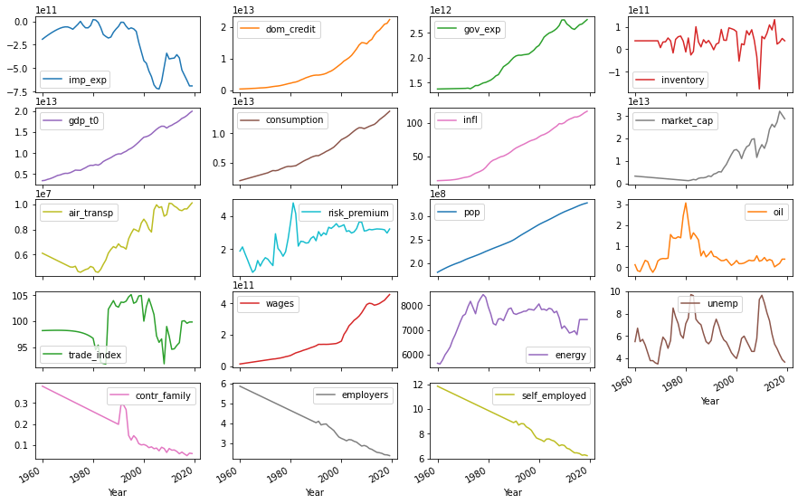

```python
df_fill.plot(subplots=True,layout= (5,4), figsize=(15,10))
```

# 4. PCA Calculation

```python
list_var_pca = ['contr_family', 'employers', 'self_employed']
df_pca = df_fill[list_var_pca]

#calculate returns in basis points
df_pca_ret = (df_pca.pct_change())[1:]
df_pca_ret.head()
```

| Year | contr_family | employers | self_employed |
| --- | --- | --- | --- |
| 1961 | -0.015908 | -0.010400 | -0.008308 |
| 1962 | -0.016165 | -0.010509 | -0.008378 |
| 1963 | -0.016431 | -0.010621 | -0.008449 |
| 1964 | -0.016705 | -0.010735 | -0.008521 |
| 1965 | -0.016989 | -0.010852 | -0.008594 |

```python
covMatrix = df_pca_ret.cov()
covMatrix
```

|  | contr_family | employers | self_employed |
| --- | --- | --- | --- |
| contr_family | 0.015821 | 0.000266 | 0.000363 |
| employers | 0.000266 | 0.000162 | 0.000143 |
| self_employed | 0.000363 | 0.000143 | 0.000132 |

```python
from numpy import linalg as LA
enval, envec = LA.eigh(covMatrix)
```

```
Eingenvalues: [1.58340295e-02 2.78676380e-04 2.93299718e-06]
Eingenvectors: [[-0.99958131 -0.02829596 -0.00604483]
 [-0.01719505  0.74894163 -0.66241283]
 [-0.02327083  0.66203155  0.74911461]]
```

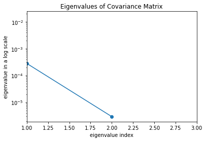

```python
#a[::-1], it starts from the end towards the first taking each element. So it reverses a
enval = enval[::-1]
print(f"Eingenvalues: {enval}")
envec = envec[:,::-1]
print(f"Eingenvectors: {envec}")

#plot eingenvalues
plt.semilogy(enval, '-o')
plt.xlim([1, enval.shape[0]])
plt.xlabel('eigenvalue index')
plt.ylabel('eigenvalue in a log scale')
plt.title('Eigenvalues of Covariance Matrix');
```

```
The number of timestamps is 59.
The number of stocks is 3.
98.25% of the variance is explained by the first 1 PCs
```

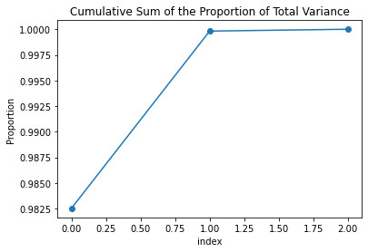

```python
from sklearn.decomposition import PCA
num_pc = 1

X = np.asarray(df_pca_ret)
[n,m] = X.shape
print ('The number of timestamps is {}.'.format(n))
print ('The number of stocks is {}.'.format(m))

pca = PCA(n_components=num_pc) # number of principal components
pca.fit(X)

percentage =  pca.explained_variance_ratio_
percentage_cum = np.cumsum(percentage)
print ('{0:.2f}% of the variance is explained by the first 1 PCs'.format(percentage_cum[-1]*100))

pca_components = pca.components_

plt.plot((enval/enval.sum()).cumsum(), '-o')
plt.title('Cumulative Sum of the Proportion of Total Variance')
plt.xlabel('index')
plt.ylabel('Proportion');
```

```
      factor_1_pca
Year
2015      0.135394
2016     -0.134709
2017     -0.138813
2018      0.239944
2019     -0.032748
```

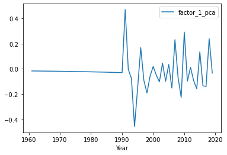

```python
factor_returns = X.dot(pca_components.T)
factor_returns = pd.DataFrame(columns=["factor_1_pca"],
                              index=df_pca_ret.index,
                              data=factor_returns)
print(factor_returns.tail())
factor_returns.plot()
```

```python
df_fill = df_fill.drop(list_var_pca, axis = 1)
df_fill['first_com_pca'] = factor_returns
```

# 5. Computation of stationary series

### Plot autocorrelation

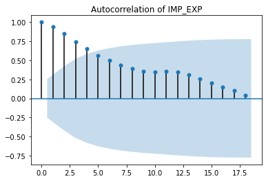

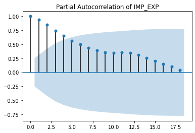

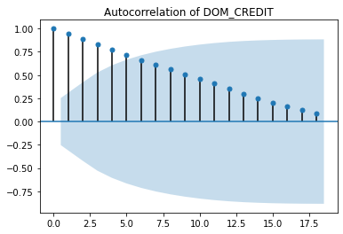

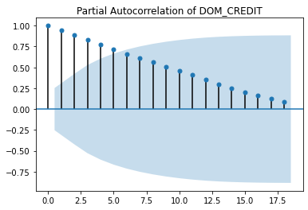

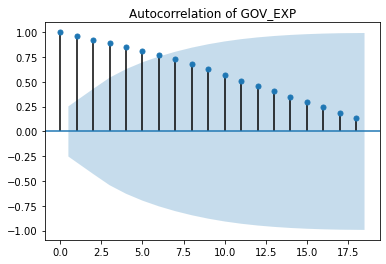

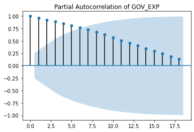

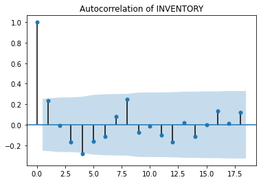

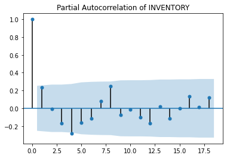

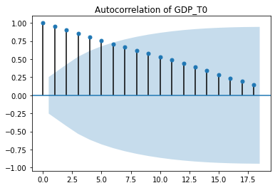

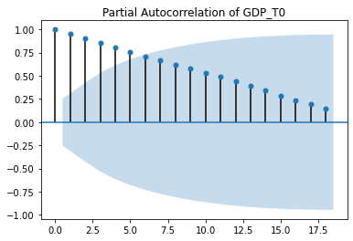

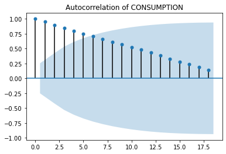

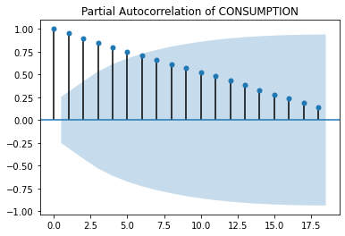

[22 more figures not shown]

```python
from statsmodels.graphics.tsaplots import plot_acf, acf
for i in df_fill.columns:
    plot_acf(df_fill[i], title = "Autocorrelation of " +str(i.upper()) )
    plot_acf(df_fill[i], title = "Partial Autocorrelation of " +str(i.upper()))
```

### Differencing non-stationary variables

```python
list_non_stat = ['imp_exp', 'dom_credit', 'gov_exp', 'gdp_t0', 'consumption', 'infl', \
                 'market_cap', 'air_transp', 'risk_premium', 'pop', 'oil', 'trade_index', 'wages']
df_fix_stat = df_fill.copy()
df_fix_stat[list_non_stat] = df_fix_stat[list_non_stat].diff()
df_fix_stat = df_fix_stat[1:]
df_fix_stat.head()
```

| Year | imp_exp | dom_credit | gov_exp | inventory | gdp_t0 | consumption | infl | market_cap | air_transp | risk_premium | pop | oil | trade_index | wages | energy | unemp | first_com_pca |
| --- | --- | --- | --- | --- | --- | --- | --- | --- | --- | --- | --- | --- | --- | --- | --- | --- | --- |
| 1961 | 2.078180e+10 | 3.009400e+10 | 1.170000e+09 | 3.754118e+10 | 7.951000e+10 | 1.214800e+11 | 0.145223 | -9.624000e+10 | -99999.83 | 0.250000 | 3020000.0 | -0.285553 | 0.016043 | 2.420000e+09 | 5612.079503 | 6.7 | -0.016273 |
| 1962 | 1.965468e+10 | 3.402800e+10 | 1.170000e+09 | 3.754118e+10 | 2.157400e+11 | 1.214800e+11 | 0.164331 | -9.624000e+10 | -99999.83 | -0.402500 | 2847000.0 | -0.041869 | 0.014225 | 2.420000e+09 | 5774.586315 | 5.5 | -0.016534 |
| 1963 | 1.847250e+10 | 3.873200e+10 | 1.170000e+09 | 3.754118e+10 | 1.651100e+11 | 1.214800e+11 | 0.171975 | -9.624000e+10 | -99999.83 | -0.378333 | 2704000.0 | 0.269320 | 0.012007 | 2.420000e+09 | 5986.783954 | 5.7 | -0.016803 |
| 1964 | 1.719848e+10 | 4.211600e+10 | 1.170000e+09 | 3.754118e+10 | 2.272200e+11 | 1.214800e+11 | 0.179618 | -9.624000e+10 | -99999.83 | -0.395833 | 2647000.0 | 0.265205 | 0.009300 | 2.420000e+09 | 6136.938230 | 5.2 | -0.017081 |
| 1965 | 1.577131e+10 | 4.844800e+10 | 1.170000e+09 | 3.754118e+10 | 2.652600e+11 | 1.214800e+11 | 0.225478 | -9.624000e+10 | -99999.83 | -0.360833 | 2414000.0 | -0.062438 | 0.005997 | 2.420000e+09 | 6307.890202 | 4.5 | -0.017368 |

### Check again stationarity

```python
from statsmodels.tsa.stattools import adfuller
# ADF Test
for i in df_fix_stat.columns:
    ts = df_fix_stat[i].dropna()
    result = adfuller(ts.values, autolag='AIC')
    stats = ["Stationaty" if result[1] < 0.05 else "Non stationary" ]
    print(f'Variable: {i.upper()}')
    print(f'ADF Statistic: {round(result[0], 3)},   P-value: {round(result[1], 4)} --> {stats}')
    print("-"*40)

for key, value in result[4].items():
    print('Critial Values:')
    print(f'   {key}, {value}')
```

```
Variable: IMP_EXP
ADF Statistic: -4.211,   P-value: 0.0006 --> ['Stationaty']
----------------------------------------
Variable: DOM_CREDIT
ADF Statistic: -0.292,   P-value: 0.9266 --> ['Non stationary']
----------------------------------------
Variable: GOV_EXP
ADF Statistic: -3.722,   P-value: 0.0038 --> ['Stationaty']
----------------------------------------
Variable: INVENTORY
ADF Statistic: -5.902,   P-value: 0.0 --> ['Stationaty']
----------------------------------------
Variable: GDP_T0
ADF Statistic: -4.833,   P-value: 0.0 --> ['Stationaty']
----------------------------------------
Variable: CONSUMPTION
ADF Statistic: -3.413,   P-value: 0.0105 --> ['Stationaty']
----------------------------------------
Variable: INFL
ADF Statistic: -3.653,   P-value: 0.0048 --> ['Stationaty']
----------------------------------------
Variable: MARKET_CAP
ADF Statistic: -0.885,   P-value: 0.7929 --> ['Non stationary']
----------------------------------------
Variable: AIR_TRANSP
ADF Statistic: -6.37,   P-value: 0.0 --> ['Stationaty']
----------------------------------------
Variable: RISK_PREMIUM
ADF Statistic: -3.641,   P-value: 0.005 --> ['Stationaty']
----------------------------------------
Variable: POP
ADF Statistic: -1.677,   P-value: 0.4433 --> ['Non stationary']
----------------------------------------
Variable: OIL
ADF Statistic: -6.805,   P-value: 0.0 --> ['Stationaty']
----------------------------------------
Variable: TRADE_INDEX
ADF Statistic: -8.541,   P-value: 0.0 --> ['Stationaty']
----------------------------------------
Variable: WAGES
ADF Statistic: -2.396,   P-value: 0.1429 --> ['Non stationary']
----------------------------------------
Variable: ENERGY
ADF Statistic: -3.25,   P-value: 0.0173 --> ['Stationaty']
----------------------------------------
Variable: UNEMP
ADF Statistic: -3.483,   P-value: 0.0084 --> ['Stationaty']
----------------------------------------
Variable: FIRST_COM_PCA
ADF Statistic: -7.011,   P-value: 0.0 --> ['Stationaty']
----------------------------------------
Critial Values:
   1%, -3.5506699942762414
Critial Values:
   5%, -2.913766394626147
Critial Values:
   10%, -2.5946240473991997
```

```python
list_non_stat2 = ['pop','market_cap', 'wages', 'dom_credit']

df_fix_stat[list_non_stat2] = df_fix_stat[list_non_stat2].diff()
df_fix_stat = df_fix_stat[1:]
df_fix_stat.head()
```

| Year | imp_exp | dom_credit | gov_exp | inventory | gdp_t0 | consumption | infl | market_cap | air_transp | risk_premium | pop | oil | trade_index | wages | energy | unemp | first_com_pca |
| --- | --- | --- | --- | --- | --- | --- | --- | --- | --- | --- | --- | --- | --- | --- | --- | --- | --- |
| 1962 | 1.965468e+10 | 3.934000e+09 | 1.170000e+09 | 3.754118e+10 | 2.157400e+11 | 1.214800e+11 | 0.164331 | -0.003906 | -99999.83 | -0.402500 | -173000.0 | -0.041869 | 0.014225 | 0.000000 | 5774.586315 | 5.5 | -0.016534 |
| 1963 | 1.847250e+10 | 4.704000e+09 | 1.170000e+09 | 3.754118e+10 | 1.651100e+11 | 1.214800e+11 | 0.171975 | 0.003906 | -99999.83 | -0.378333 | -143000.0 | 0.269320 | 0.012007 | 0.000061 | 5986.783954 | 5.7 | -0.016803 |
| 1964 | 1.719848e+10 | 3.384000e+09 | 1.170000e+09 | 3.754118e+10 | 2.272200e+11 | 1.214800e+11 | 0.179618 | 0.000000 | -99999.83 | -0.395833 | -57000.0 | 0.265205 | 0.009300 | 0.000000 | 6136.938230 | 5.2 | -0.017081 |
| 1965 | 1.577131e+10 | 6.332000e+09 | 1.170000e+09 | 3.754118e+10 | 2.652600e+11 | 1.214800e+11 | 0.225478 | 0.000000 | -99999.83 | -0.360833 | -233000.0 | -0.062438 | 0.005997 | 0.000000 | 6307.890202 | 4.5 | -0.017368 |
| 1966 | 1.408874e+10 | -1.699900e+10 | 1.170000e+09 | 3.754118e+10 | 2.866500e+11 | 1.214800e+11 | 0.435669 | 0.000000 | -99999.83 | 0.156667 | -157000.0 | -0.321225 | 0.001964 | 0.000000 | 6591.340558 | 3.8 | -0.017666 |

```python
from statsmodels.tsa.stattools import adfuller
# ADF Test
for i in df_fix_stat.columns:
    ts = df_fix_stat[i].dropna()
    result = adfuller(ts.values, autolag='AIC')
    stats = ["Stationaty" if result[1] < 0.05 else "Non stationary" ]
    print(f'Variable: {i.upper()}')
    print(f'ADF Statistic: {round(result[0], 3)},   P-value: {round(result[1], 4)} --> {stats}')
    print("-"*40)

for key, value in result[4].items():
    print('Critial Values:')
    print(f'   {key}, {value}')
```

```
Variable: IMP_EXP
ADF Statistic: -4.183,   P-value: 0.0007 --> ['Stationaty']
----------------------------------------
Variable: DOM_CREDIT
ADF Statistic: -2.704,   P-value: 0.0733 --> ['Non stationary']
----------------------------------------
Variable: GOV_EXP
ADF Statistic: -3.728,   P-value: 0.0037 --> ['Stationaty']
----------------------------------------
Variable: INVENTORY
ADF Statistic: -5.849,   P-value: 0.0 --> ['Stationaty']
----------------------------------------
Variable: GDP_T0
ADF Statistic: -4.735,   P-value: 0.0001 --> ['Stationaty']
----------------------------------------
Variable: CONSUMPTION
ADF Statistic: -3.404,   P-value: 0.0108 --> ['Stationaty']
----------------------------------------
Variable: INFL
ADF Statistic: -3.76,   P-value: 0.0033 --> ['Stationaty']
----------------------------------------
Variable: MARKET_CAP
ADF Statistic: -0.999,   P-value: 0.7537 --> ['Non stationary']
----------------------------------------
Variable: AIR_TRANSP
ADF Statistic: -6.346,   P-value: 0.0 --> ['Stationaty']
----------------------------------------
Variable: RISK_PREMIUM
ADF Statistic: -3.485,   P-value: 0.0084 --> ['Stationaty']
----------------------------------------
Variable: POP
ADF Statistic: -4.893,   P-value: 0.0 --> ['Stationaty']
----------------------------------------
Variable: OIL
ADF Statistic: -6.678,   P-value: 0.0 --> ['Stationaty']
----------------------------------------
Variable: TRADE_INDEX
ADF Statistic: -8.465,   P-value: 0.0 --> ['Stationaty']
----------------------------------------
Variable: WAGES
ADF Statistic: -5.631,   P-value: 0.0 --> ['Stationaty']
----------------------------------------
Variable: ENERGY
ADF Statistic: -3.177,   P-value: 0.0214 --> ['Stationaty']
----------------------------------------
Variable: UNEMP
ADF Statistic: -3.478,   P-value: 0.0086 --> ['Stationaty']
----------------------------------------
Variable: FIRST_COM_PCA
ADF Statistic: -6.946,   P-value: 0.0 --> ['Stationaty']
----------------------------------------
Critial Values:
   1%, -3.552928203580539
Critial Values:
   5%, -2.9147306250000002
Critial Values:
   10%, -2.595137155612245
```

### market_cap and dom_credit remain not-stationary after the second oreder difference. They are then removed from the set of features

```python
df_fix_stat = df_fix_stat.drop(['market_cap', 'dom_credit'], axis = 1)
df_fix_stat.shape
```

```
(58, 15)
```

### Plot stationary series

```
array([[<matplotlib.axes._subplots.AxesSubplot object at 0x0000024F46CA7610>,
      dtype=object)
```

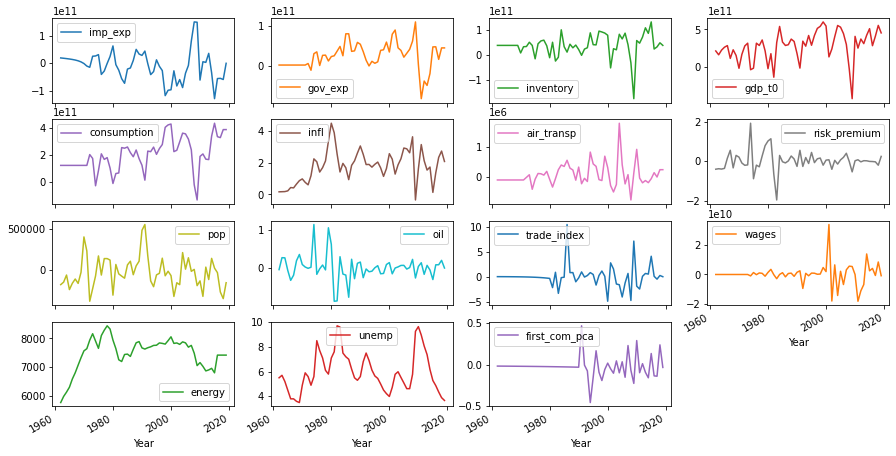

```python
df_fix_stat.plot(subplots=True,layout= (5,4),figsize=(15,10))
```

# 6. Train-Test Split

```python
#Forecasting Horizon = 5 years
n_obs_test = 5
X_train, X_test = df_fix_stat[0:-n_obs_test], df_fix_stat[-n_obs_test:]
print(f"Shape of Train: {X_train.shape}")
print(f"Shape of Test: {X_test.shape}")
```

```
Shape of Train: (53, 15)
Shape of Test: (5, 15)
```

# 7. Check Granger Causality

```python
df_check_cas = df_fix_stat.copy()

from statsmodels.tsa.stattools import grangercausalitytests

maxlag=5
test = 'ssr-chi2test'
def grangers_causality_matrix(X_train, variables, test = 'ssr_chi2test', verbose=False):
    dataset = pd.DataFrame(np.zeros((len(variables), len(variables))), columns=variables, index=variables)

    for c in dataset.columns:
        for r in dataset.index:
            test_result = grangercausalitytests(X_train[[r,c]], maxlag=maxlag, verbose=False)
            p_values = [round(test_result[i+1][0][test][1],4) for i in range(maxlag)]
            if verbose: print(f'Y = {r}, X = {c}, P Values = {p_values}')
            min_p_value = np.min(p_values)
            dataset.loc[r,c] = min_p_value
    dataset.columns = [var + '_x' for var in variables]
    dataset.index = [var + '_y' for var in variables]

    return dataset

grangers_causality_matrix(X_train, variables = X_train.columns)
```

|  | imp_exp_x | gov_exp_x | inventory_x | gdp_t0_x | consumption_x | infl_x | air_transp_x | risk_premium_x | pop_x | oil_x | trade_index_x | wages_x | energy_x | unemp_x | first_com_pca_x |
| --- | --- | --- | --- | --- | --- | --- | --- | --- | --- | --- | --- | --- | --- | --- | --- |
| imp_exp_y | 1.0000 | 0.0008 | 0.0000 | 0.0005 | 0.0089 | 0.0000 | 0.1619 | 0.0248 | 0.3297 | 0.0873 | 0.0111 | 0.0279 | 0.0290 | 0.0001 | 0.0058 |
| gov_exp_y | 0.0000 | 1.0000 | 0.0000 | 0.0000 | 0.0000 | 0.0003 | 0.0000 | 0.0708 | 0.2477 | 0.5775 | 0.0006 | 0.0810 | 0.0001 | 0.0010 | 0.0659 |
| inventory_y | 0.0003 | 0.1436 | 1.0000 | 0.0154 | 0.0011 | 0.0008 | 0.0744 | 0.0114 | 0.0539 | 0.3542 | 0.0185 | 0.0136 | 0.2365 | 0.0552 | 0.0016 |
| gdp_t0_y | 0.0010 | 0.3938 | 0.0239 | 1.0000 | 0.0002 | 0.0001 | 0.0976 | 0.0036 | 0.0306 | 0.0893 | 0.0083 | 0.4160 | 0.0885 | 0.0026 | 0.1218 |
| consumption_y | 0.0012 | 0.2233 | 0.1879 | 0.0649 | 1.0000 | 0.0019 | 0.6733 | 0.2729 | 0.0456 | 0.0722 | 0.0232 | 0.4405 | 0.0602 | 0.0050 | 0.2069 |
| infl_y | 0.1213 | 0.0495 | 0.1628 | 0.0358 | 0.0507 | 1.0000 | 0.0000 | 0.4170 | 0.6265 | 0.1905 | 0.0274 | 0.2911 | 0.0002 | 0.3414 | 0.0167 |
| air_transp_y | 0.1802 | 0.0304 | 0.1231 | 0.3962 | 0.1654 | 0.0052 | 1.0000 | 0.2736 | 0.6586 | 0.0629 | 0.3140 | 0.0013 | 0.2020 | 0.0748 | 0.0183 |
| risk_premium_y | 0.3498 | 0.3458 | 0.1557 | 0.0247 | 0.2622 | 0.1213 | 0.0777 | 1.0000 | 0.0068 | 0.0004 | 0.7760 | 0.3686 | 0.0127 | 0.0380 | 0.5650 |
| pop_y | 0.2139 | 0.0905 | 0.1584 | 0.1016 | 0.4601 | 0.2175 | 0.5867 | 0.2174 | 1.0000 | 0.3046 | 0.0019 | 0.1439 | 0.2005 | 0.2470 | 0.8268 |
| oil_y | 0.8501 | 0.2718 | 0.6157 | 0.5162 | 0.3421 | 0.0209 | 0.4052 | 0.1964 | 0.4499 | 1.0000 | 0.0514 | 0.8613 | 0.0009 | 0.0777 | 0.6141 |
| trade_index_y | 0.1847 | 0.0656 | 0.1824 | 0.0508 | 0.0668 | 0.0426 | 0.0026 | 0.0380 | 0.5783 | 0.0050 | 1.0000 | 0.2428 | 0.0082 | 0.0611 | 0.0411 |
| wages_y | 0.0263 | 0.0157 | 0.0000 | 0.0143 | 0.0350 | 0.8191 | 0.2076 | 0.7813 | 0.7229 | 0.3582 | 0.4201 | 1.0000 | 0.2870 | 0.0063 | 0.0878 |
| energy_y | 0.0243 | 0.2196 | 0.0996 | 0.3653 | 0.1255 | 0.0000 | 0.0775 | 0.0003 | 0.0064 | 0.0013 | 0.0029 | 0.6280 | 1.0000 | 0.0446 | 0.2553 |
| unemp_y | 0.0001 | 0.0517 | 0.0034 | 0.0000 | 0.0000 | 0.0000 | 0.0058 | 0.0000 | 0.0039 | 0.0224 | 0.1893 | 0.0570 | 0.0016 | 1.0000 | 0.4234 |
| first_com_pca_y | 0.1856 | 0.0701 | 0.0733 | 0.0778 | 0.0866 | 0.0338 | 0.0035 | 0.5754 | 0.0236 | 0.8032 | 0.0412 | 0.0531 | 0.2183 | 0.1508 | 1.0000 |

### Variable selection post causality test

```python
variable_selection = [ 'infl', 'imp_exp', 'inventory','consumption', 'unemp', 'risk_premium','gdp_t0', 'pop', 'oil', 'trade_index', 'energy']
X_train_sel = X_train[variable_selection]
X_test_sel = X_test[variable_selection]
```

# 8. Model Estimation

### Check best fit fot VAR model

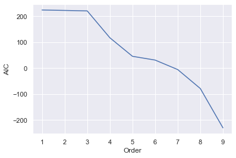

```python
from statsmodels.tsa.api import VAR
import seaborn as sns
#check the best fit for VAR parameter
forecasting_model = VAR(X_train_sel)
results_aic = []
for p in range(1,10):
    try:
      results = forecasting_model.fit(p)
      results_aic.append(results.aic)
    except:
      results_aic.append(np.NaN)

sns.set()
plt.plot(list(np.arange(1,10,1)), results_aic)
plt.xlabel("Order")
plt.ylabel("AIC")
plt.show()
```

### Model Estimation

```python
mod = VAR(X_train_sel)
mod.select_order(2)
res = mod.fit(2, ic='aic')
res.summary()
```

```
  Summary of Regression Results
==================================
Model:                         VAR
Method:                        OLS
Date:           Mon, 07, Dec, 2020
Time:                     17:18:59
--------------------------------------------------------------------
No. of Equations:         11.0000    BIC:                    231.914
Nobs:                     51.0000    HQIC:                   225.993
Log likelihood:          -6212.46    FPE:                7.77931e+96
AIC:                      222.331    Det(Omega_mle):     1.29618e+95
--------------------------------------------------------------------
Results for equation infl
==================================================================================
                     coefficient       std. error           t-stat            prob
----------------------------------------------------------------------------------
const                  -3.056519         2.021971           -1.512           0.131
L1.infl                 0.752557         0.304757            2.469           0.014
L1.imp_exp              0.000000         0.000000            1.417           0.156
L1.inventory           -0.000000         0.000000           -0.157           0.875
L1.consumption          0.000000         0.000000            1.195           0.232
L1.unemp                0.185566         0.418921            0.443           0.658
L1.risk_premium         0.151420         0.331634            0.457           0.648
L1.gdp_t0               0.000000         0.000000            0.753           0.452
L1.pop                 -0.000000         0.000001           -0.230           0.818
L1.oil                  1.100445         0.387763            2.838           0.005
L1.trade_index          0.228944         0.073288            3.124           0.002
L1.energy               0.000889         0.001263            0.704           0.482
L2.infl                 0.154726         0.214118            0.723           0.470
L2.imp_exp             -0.000000         0.000000           -1.005           0.315
L2.inventory           -0.000000         0.000000           -0.673           0.501
L2.consumption         -0.000000         0.000000           -2.639           0.008
L2.unemp               -0.269793         0.395896           -0.681           0.496
L2.risk_premium        -0.324874         0.418238           -0.777           0.437
L2.gdp_t0               0.000000         0.000000            0.838           0.402
L2.pop                 -0.000001         0.000001           -1.047           0.295
L2.oil                 -0.393333         0.390039           -1.008           0.313
L2.trade_index         -0.027757         0.063729           -0.436           0.663
L2.energy              -0.000416         0.001366           -0.304           0.761
==================================================================================
```

[output cut: 289 more lines]

```
==================================================================================

Correlation matrix of residuals
                    infl   imp_exp  inventory  consumption     unemp  risk_premium    gdp_t0       pop       oil  trade_index    energy
infl            1.000000  0.277317   0.269520    -0.142254 -0.376309      0.279185  0.141036 -0.061386  0.500027    -0.671048 -0.153743
imp_exp         0.277317  1.000000  -0.478967    -0.680195  0.296717      0.037562 -0.490488 -0.236108  0.100591     0.042144 -0.182311
inventory       0.269520 -0.478967   1.000000     0.654011 -0.781132      0.204809  0.809480  0.436150  0.151933    -0.525331  0.406716
consumption    -0.142254 -0.680195   0.654011     1.000000 -0.574029     -0.275932  0.846098  0.348178 -0.074286    -0.320741  0.630538
unemp          -0.376309  0.296717  -0.781132    -0.574029  1.000000     -0.096344 -0.823908 -0.175323 -0.131830     0.505381 -0.496398
risk_premium    0.279185  0.037562   0.204809    -0.275932 -0.096344      1.000000 -0.145502 -0.287135  0.238547     0.062438 -0.286300
gdp_t0          0.141036 -0.490488   0.809480     0.846098 -0.823908     -0.145502  1.000000  0.301505  0.065139    -0.555683  0.521834
pop            -0.061386 -0.236108   0.436150     0.348178 -0.175323     -0.287135  0.301505  1.000000 -0.240930    -0.071873  0.302820
oil             0.500027  0.100591   0.151933    -0.074286 -0.131830      0.238547  0.065139 -0.240930  1.000000    -0.369164 -0.274584
trade_index    -0.671048  0.042144  -0.525331    -0.320741  0.505381      0.062438 -0.555683 -0.071873 -0.369164     1.000000 -0.172990
energy         -0.153743 -0.182311   0.406716     0.630538 -0.496398     -0.286300  0.521834  0.302820 -0.274584    -0.172990  1.000000
```

### Plot fitted series

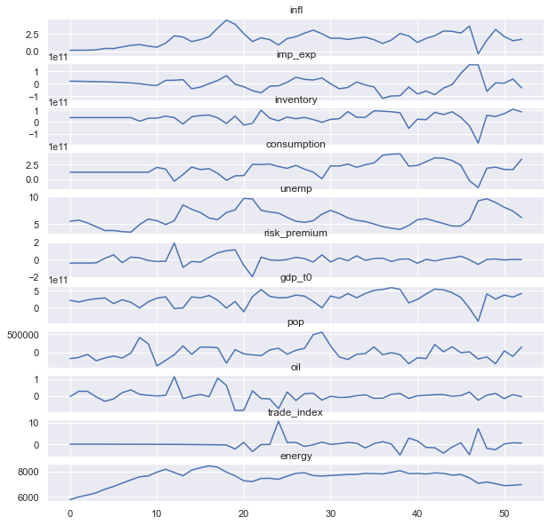

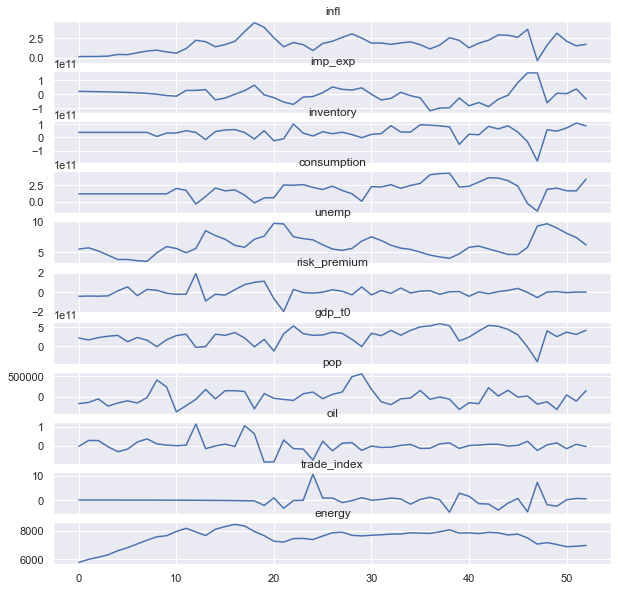

```python
res.plot()
```

### Residuals

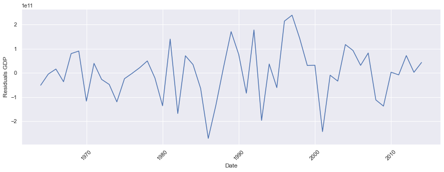

```python
y_fitted = res.fittedvalues
plt.figure(figsize = (15,5))
plt.plot(res.resid['gdp_t0'], label='resid')
plt.xlabel('Date')
plt.xticks(rotation=45)
plt.ylabel('Residuals GDP')
plt.grid(True)
```

### Check autocorrelation in residuals

```python
#check for autocorrelation in residuals
from statsmodels.stats.stattools import durbin_watson
check_res = durbin_watson(res.resid)
check_res

for col, val in zip(X_train_sel.columns, check_res):
    print((col), ": ", round(val, 2) )
```

```
infl :  2.04
imp_exp :  1.93
inventory :  2.1
consumption :  1.9
unemp :  2.05
risk_premium :  2.23
gdp_t0 :  1.86
pop :  2.04
oil :  2.06
trade_index :  2.04
energy :  1.9
```

The result for Durbin-Watson test is close to 2 for each variable. This confirm a low degree of autocorrelation in residuals

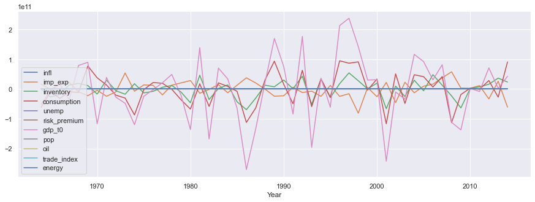

```python
r = res.resid
r.plot(figsize=(15,5))
```

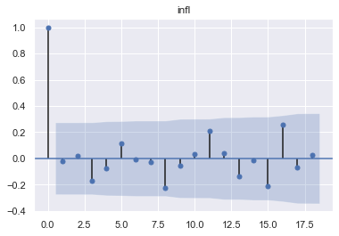

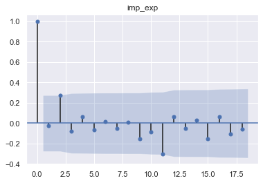

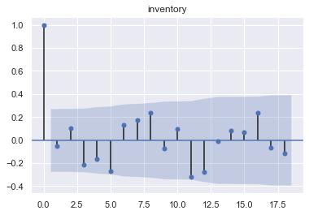

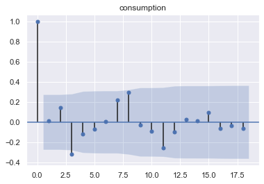

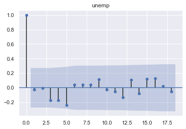

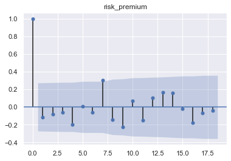

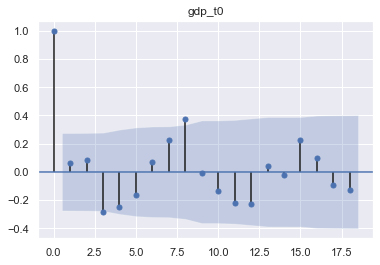

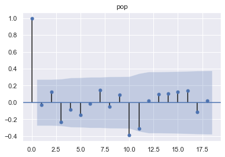

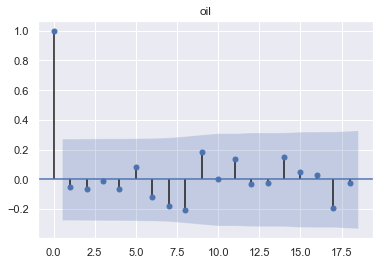

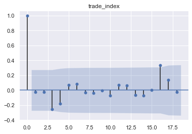

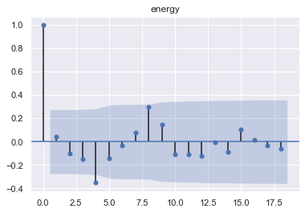

```python
for i in res.resid:
    plot_acf(res.resid[i], title= i)
```

# 9. Forecasting GDP

### Fitted GDP vs Real GDP

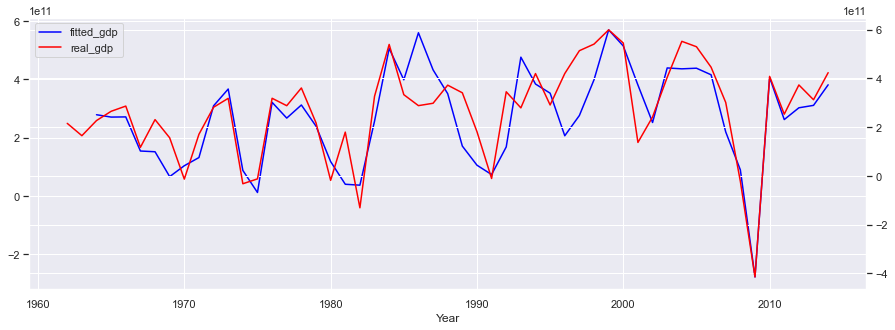

```python
plt.figure(figsize=(15,5))
plt.xlabel('Number of requests every 10 minutes')

ax1 = y_fitted['gdp_t0'].plot(color='blue', grid=True, label='fitted_gdp')
ax2 = X_train_sel['gdp_t0'].plot(color='red', grid=True, secondary_y=True, label='real_gdp')

h1, l1 = ax1.get_legend_handles_labels()
h2, l2 = ax2.get_legend_handles_labels()


plt.legend(h1+h2, l1+l2, loc=2)
plt.show()
```

### Prediction

```python
# Get the lag order
lag_order = res.k_ar
lag_order
```

```
2
```

The forecast is not done considersing a 5 year forecasting horizon. But 5 times a 1-year forecast, as requested in the assignement

```python
df_forecast = df_fix_stat[variable_selection].copy()
data = df_forecast.iloc[-(lag_order+n_obs_test):, :]

df_preds = pd.DataFrame(columns=df_forecast.columns + '_pred')
for i in range(2,len(data)):
    input_arr = data.iloc[i-2:i,:].values
    pred = res.forecast(y=input_arr, steps=1)
    pred = (pd.DataFrame(pred, columns=df_forecast.columns + '_pred'))
    df_preds = df_preds.append(pred)
```

```python
df_preds.index= X_test_sel.index
df_preds
```

| Year | infl_pred | imp_exp_pred | inventory_pred | consumption_pred | unemp_pred | risk_premium_pred | gdp_t0_pred | pop_pred | oil_pred | trade_index_pred | energy_pred |
| --- | --- | --- | --- | --- | --- | --- | --- | --- | --- | --- | --- |
| 2015 | 1.775998 | 4.704461e+10 | 5.419572e+10 | 1.033847e+11 | 5.990211 | -0.567370 | 1.957745e+11 | 166022.761074 | 0.083988 | 0.355407 | 7164.065681 |
| 2016 | 0.200384 | -3.877504e+10 | 1.245549e+11 | 4.646646e+11 | 3.773291 | -1.019434 | 6.803128e+11 | -388196.086497 | -0.331277 | 1.065473 | 7348.363144 |
| 2017 | 0.393075 | 3.666901e+10 | -1.402686e+10 | 1.733000e+11 | 4.763085 | -1.464774 | 2.646196e+11 | -38644.247647 | -0.028161 | 1.092243 | 7677.914141 |
| 2018 | 1.862674 | 3.406454e+10 | 2.727204e+10 | 1.374676e+11 | 4.511308 | 0.026331 | 1.947893e+11 | -309596.240292 | -0.109184 | -0.826660 | 7490.525068 |
| 2019 | 3.626875 | -3.391826e+10 | 4.612694e+10 | 2.294352e+11 | 4.065074 | 0.743975 | 2.884692e+11 | 65963.631851 | -0.072691 | -4.673206 | 7301.066719 |

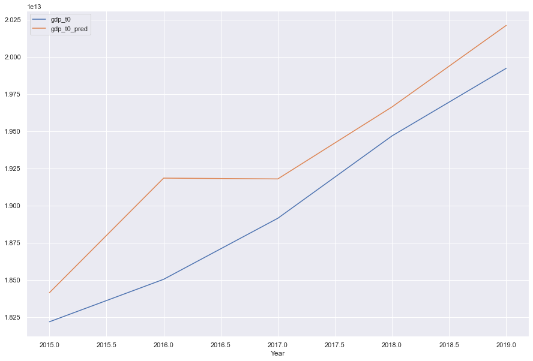

```python
#combining predicted and real data set
combine = pd.merge(df_fill['gdp_t0'], df_preds, how = 'left', left_index = True, right_index= True)[['gdp_t0','gdp_t0_pred']]
combine['gdp_t0_pred'] = combine['gdp_t0'] + combine['gdp_t0_pred']
combine.iloc[-5:].plot(figsize = (15,10))
```

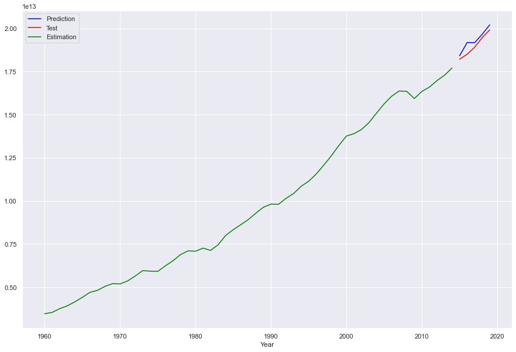

```python
plt.figure(figsize = (15,10))
combine.loc[-5:,'gdp_t0_pred'].plot(label = "Prediction", legend = True, color = 'Blue')
combine['gdp_t0'][-5:].plot(label = "Test", legend = True, color = 'red')
combine['gdp_t0'][:-5].plot(label = "Estimation", legend = True, color = 'green')
plt.show()
```

# Model performance metrics

```python
combine = combine.iloc[-5:, :].reset_index()
combine['perc_diff'] = (combine['gdp_t0_pred'] - combine['gdp_t0']) / combine['gdp_t0']
combine.head()
```

|  | Year | gdp_t0 | gdp_t0_pred | perc_diff |
| --- | --- | --- | --- | --- |
| 0 | 2015 | 1.821930e+13 | 1.841507e+13 | 0.010745 |
| 1 | 2016 | 1.850480e+13 | 1.918511e+13 | 0.036764 |
| 2 | 2017 | 1.891510e+13 | 1.917972e+13 | 0.013990 |
| 3 | 2018 | 1.946880e+13 | 1.966359e+13 | 0.010005 |
| 4 | 2019 | 1.992310e+13 | 2.021157e+13 | 0.014479 |

### In absolute value

```python
from sklearn.metrics import mean_absolute_error, mean_squared_error
#Forecast bias
forecast_errors = [(combine['gdp_t0'][i]- combine['gdp_t0_pred'][i]) for i in range(len(combine['gdp_t0']))]
bias = sum(forecast_errors) * 1.0/len(combine['gdp_t0'])
print('Bias: %f' % bias)
print('Mean absolute error:', mean_absolute_error(combine['gdp_t0'].values, combine['gdp_t0_pred'].values))
print('Mean squared error:', mean_squared_error(combine['gdp_t0'].values, combine['gdp_t0_pred'].values))
print('Root mean squared error:', np.sqrt(mean_squared_error(combine['gdp_t0'].values, combine['gdp_t0_pred'].values)))
```

```
Bias: -324793083475.935913
Mean absolute error: 324793083475.9359
Mean squared error: 1.3846681232384307e+23
Root mean squared error: 372111290239.685
```

### In percentage value

Respect to the last gdp value

```python
#Forecast bias
forecast_errors = [(combine['gdp_t0_pred'][i] - combine['gdp_t0'][i])/combine['gdp_t0'][i]  for i in range(len(combine['gdp_t0']))]
bias = sum(forecast_errors) * 1.0/len(combine['gdp_t0'])
print('Bias: %f' % bias)
print('Mean absolute error:', mean_absolute_error(combine['gdp_t0'].values, combine['gdp_t0_pred'].values)/ combine['gdp_t0'].values[-1])
print('Mean squared error:', mean_squared_error(combine['gdp_t0'].values, combine['gdp_t0_pred'].values)/ combine['gdp_t0'].values[-1])
print('Root mean squared error:', np.sqrt(mean_squared_error(combine['gdp_t0'].values, combine['gdp_t0_pred'].values)/combine['gdp_t0'].values[-1]))
```

```
Bias: 0.017197
Mean absolute error: 0.01630233665824776
Mean squared error: 6950063610.775585
Root mean squared error: 83367.04151387156
```